# Reproducible Research Week 2 Assignment

## Brief Analysis of Personal Activity Data

This is a step-by-step guide to the analysis of the Personal Activity Data. Our goal is to analyze personal activity data to see if there are any discernable patterns in behaviors. The data set can be downloaded [here](https://d396qusza40orc.cloudfront.net/repdata%2Fdata%2Factivity.zip).

### Loading and preprocessing the data

Let’s read the data from file, `activity.csv`, and store it as a tibble.

```r
## Require packages
require(dplyr)
require(ggplot2)
require(lubridate)
require(scales)
```

```r
act <- read.csv("activity.csv")
```

### What is mean total number of steps taken per day?

Group the data by days and calculate the total number of steps taken per day:

```r
act_date <- group_by(act,date)
days_sum_steps <- summarize(act_date,tot_mon_steps = sum(steps))
```

The mean number of steps taken per day (while removing days containing no information, i.e. `NA`’s) is

```r
step_mean <- mean(days_sum_steps$tot_mon_steps,na.rm = TRUE)
step_mean
```

```
## [1] 10766.19
```

The median number of steps taken per day (while removing days containing no information, i.e. `NA`’s) is

```r
step_median <- median(days_sum_steps$tot_mon_steps,na.rm = TRUE)
step_median
```

```
## [1] 10765
```

Below is a histogram containing steps taken per day:

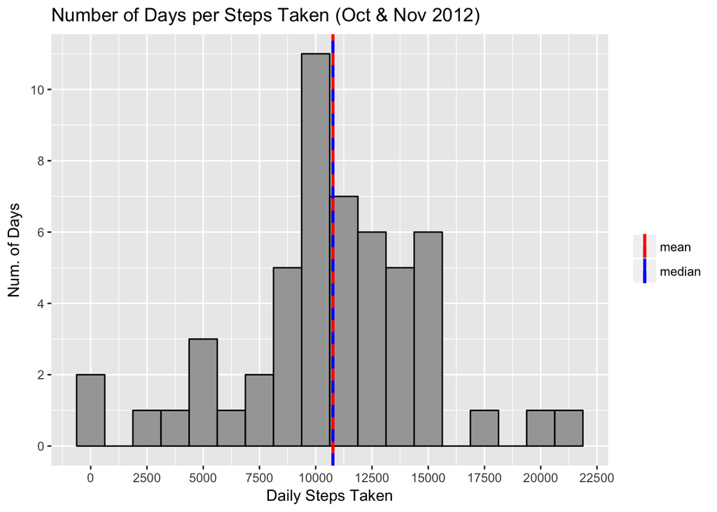

```r
g1a <- ggplot(days_sum_steps, aes(tot_mon_steps) ) +
      geom_histogram(binwidth = 1250, color = "grey1", fill = "grey65") +
      geom_vline(aes(xintercept=step_mean,
                  color = "mean"), lwd = 1, lty = 1) +
      geom_vline(aes(xintercept=step_median,
                  color = "median"), lwd = 1, lty = 2) +
      ggtitle("Number of Days per Steps Taken (Oct & Nov 2012)") +
      xlab("Daily Steps Taken") + ylab("Num. of Days") +
      scale_x_continuous(breaks = seq(0,30000,by=2500),position = "bottom") +
      scale_y_continuous(breaks = seq(0,14,by=2), position = "left") +
      scale_color_manual("",breaks = c("mean","median"),
                  values = c("red","blue"))
print(g1a)
```

Below is a bar plot which I think is a bit more informative in showing any pattern over all days, containing the total number of steps per day:

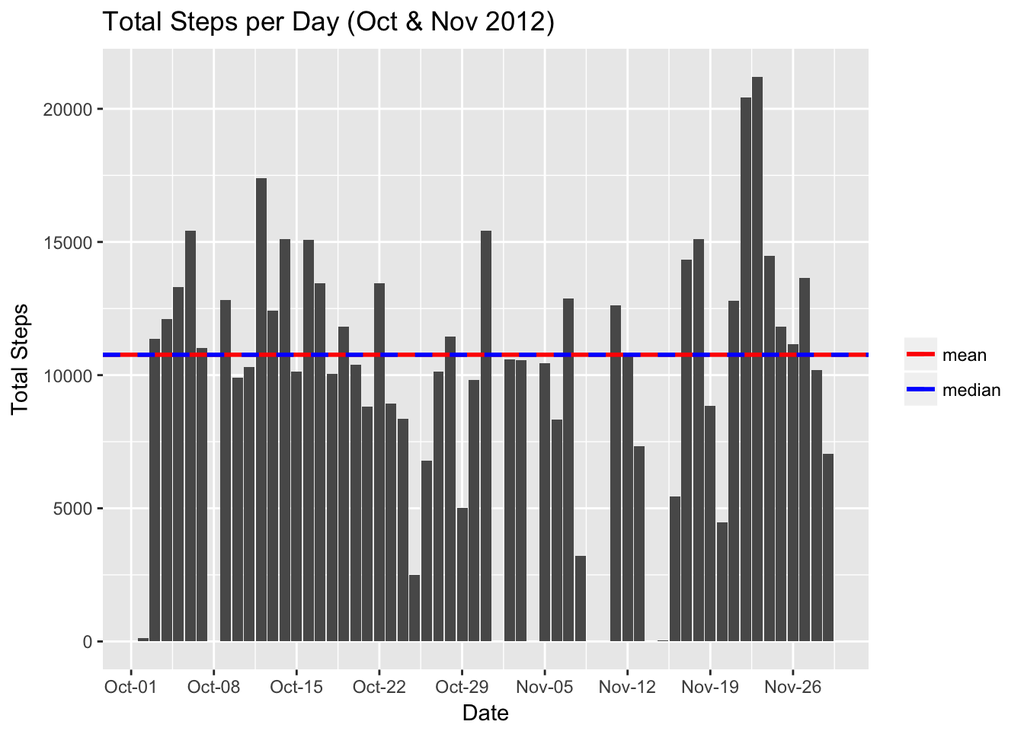

```r
g1b <- ggplot(days_sum_steps, aes(as.Date(date),tot_mon_steps) ) +
      geom_bar(stat="identity") +
      geom_hline(aes(yintercept=step_mean,
                  color = "mean"), lwd = 1, lty = 1) +
      geom_hline(aes(yintercept=step_median,
                  color = "median"), lwd = 1, lty = 2) +
      ggtitle("Total Steps per Day (Oct & Nov 2012)") +
      xlab("Date") + ylab("Total Steps") +
      scale_x_date(date_labels="%b-%d",date_breaks="1 week") +
      scale_color_manual("",breaks = c("mean","median"),
                  values = c("red","blue"))
print(g1b)
```

### What is the average daily activity pattern?

Rather than looking at the total steps taken each day, let’s try to gain some insight by looking at the steps per interval. For each interval throughout the day, average the steps over all days for that particular interval.

Group by interval and average the number of steps over all days:

```r
act_interval <- group_by(act,interval)
int_avg_steps <- summarize(act_interval,
                  avg_int_steps = mean(steps,na.rm = TRUE))
```

Below is a plot showing the average steps over all days for each interval.

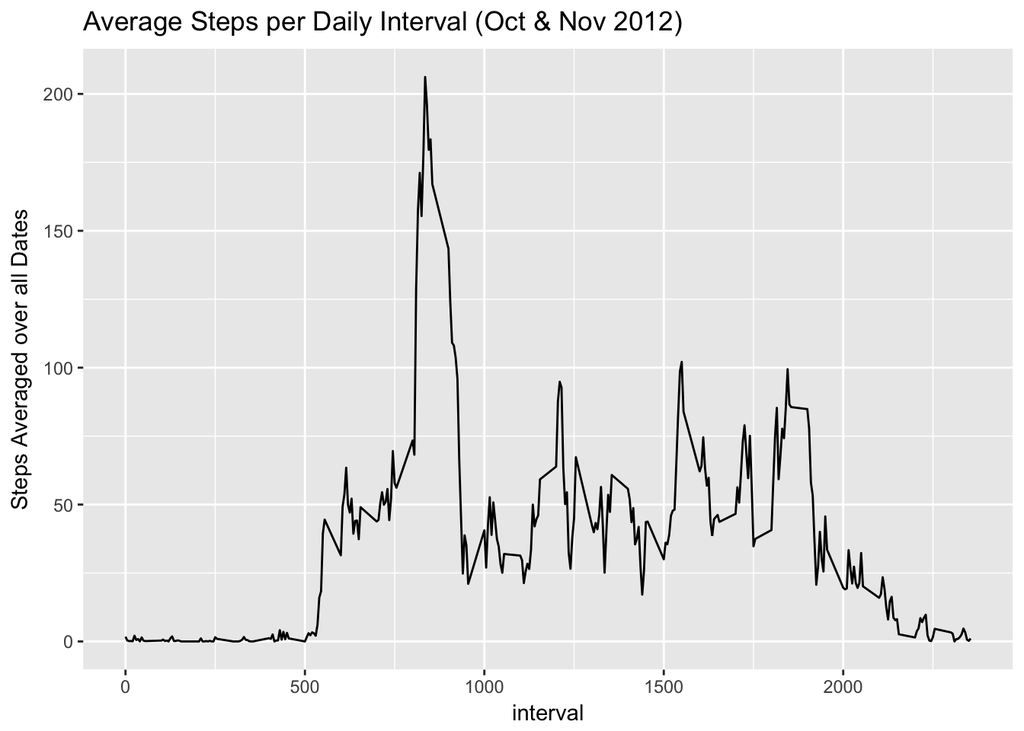

```r
g2 <- ggplot(int_avg_steps,aes(x=interval,y=avg_int_steps)) +
      geom_line() + ggtitle("Average Steps per Daily Interval (Oct & Nov 2012)") +
      ylab("Intervals") + ylab("Steps Averaged over all Dates")
print(g2)
```

On average, the interval with the most steps is 835 with 206.2 average steps. See below:

```r
int_avg_steps[which.max(int_avg_steps$avg_int_steps),]
```

```
## # A tibble: 1 × 2
##   interval avg_int_steps
##      <int>         <dbl>
## 1      835      206.1698
```

### Imputing missing values

In the data used above, there were entries missing values, i.e. entries with `NA`’s. For the analysis above, the entries with no values were excluded.

Total number of intervals over all days missing data

```r
sum(is.na(act$steps))
```

```
## [1] 2304
```

We’ll try to impute the missing values. Below is the process followed:

1. Find all entries that are missing values.

```r
## entries that are NA's
na_entry <- is.na(act_interval$steps)
```

2. Find the dates that correspond to the missing entries.

```r
## Dates that are contain NA's
na_dates <- unique(act_interval$date[na_entry])
```

3. Create a vector containing all the dates in the data set, in order.

```r
## All dates in study
the_dates <- levels(act_interval$date)
```

4. Create a vector of matching length to index the dates in order.

```r
## Indices of Dates in order
date_indices <- c(1:length(the_dates))
```

5. Now, find the indices of the dates that contain `NA` entries.

```r
## Indices that match na_dates
na_date_indices <- date_indices[is.element(the_dates,na_dates)]
na_date_indices
```

```
## [1]  1  8 32 35 40 41 45 61
```

6. Create a complete list of the intervals in a day (12 5-min intervals per hour, 24 hours in a day: 12 x 24 = 288 total intervals in a day).

```r
## 24 hrs of interval values
interval_list <- unique(act_interval$interval)
```

7. Make a copy of the data set, and use the copy to fill in the missing values.

```r
## Make a copy of act_interval
imputed_act_interval <- act_interval
```

8. Now, take the missing values and fill them in. Take a date with missing values, and for each interval, fill it with the average of the steps taken the day before and the day after for that same interval.

```r
for(d_index in na_date_indices){
      temp_ind <- intersect(date_indices,c(d_index-1,d_index+1))
      imputed_act_interval[
            imputed_act_interval$date == the_dates[d_index],]$steps =
            summarize(imputed_act_interval[
            is.element(imputed_act_interval$date,the_dates[temp_ind]),],
            steps = mean(steps,na.rm = TRUE))$steps
}
```

Group by date and find the total number of steps taken each day:

```r
imputed_days_sum_steps <- summarize(group_by(imputed_act_interval,date),
                            tot_mon_steps = sum(steps))
```

The mean daily steps taken with imputed data is now

```r
imputed_step_mean <- mean(imputed_days_sum_steps$tot_mon_steps)
imputed_step_mean
```

```
## [1] 10295.52
```

And the median daily steps taken with imputed data is now

```r
imputed_step_median <- median(imputed_days_sum_steps$tot_mon_steps)
imputed_step_median
```

```
## [1] 10571
```

It looks like this method of imputing the missing data has lowered the median by about 200 steps, but lowered the average more so by about 400 steps. This can be seen in the plots below.

Below is a histogram containing the total number of steps per day:

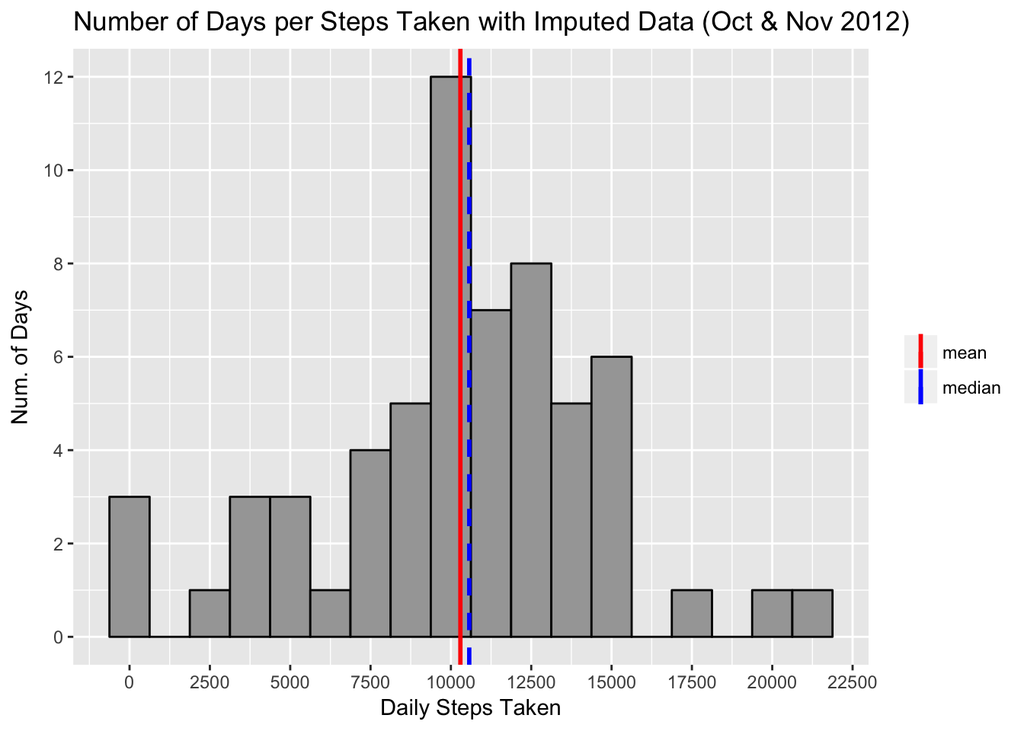

```r
g3a <- ggplot(imputed_days_sum_steps, aes(tot_mon_steps) ) +
      geom_histogram(binwidth = 1250, color = "grey1", fill = "grey65") +
      geom_vline(aes(xintercept=imputed_step_mean,
                  color = "mean"), lwd = 1, lty = 1) +
      geom_vline(aes(xintercept=imputed_step_median,
                  color = "median"), lwd = 1, lty = 2) +
      ggtitle("Number of Days per Steps Taken with Imputed Data (Oct & Nov 2012)") +
      xlab("Daily Steps Taken") + ylab("Num. of Days") +
      scale_x_continuous(breaks = seq(0,30000,by=2500),position = "bottom") +
      scale_y_continuous(breaks = seq(0,14,by=2), position = "left") +
      scale_color_manual("",breaks = c("mean","median"),
                  values = c("red","blue"))
print(g3a)
```

As with the data set with missing values, an alternative way of viewing the information is to look at the total number of steps per day:

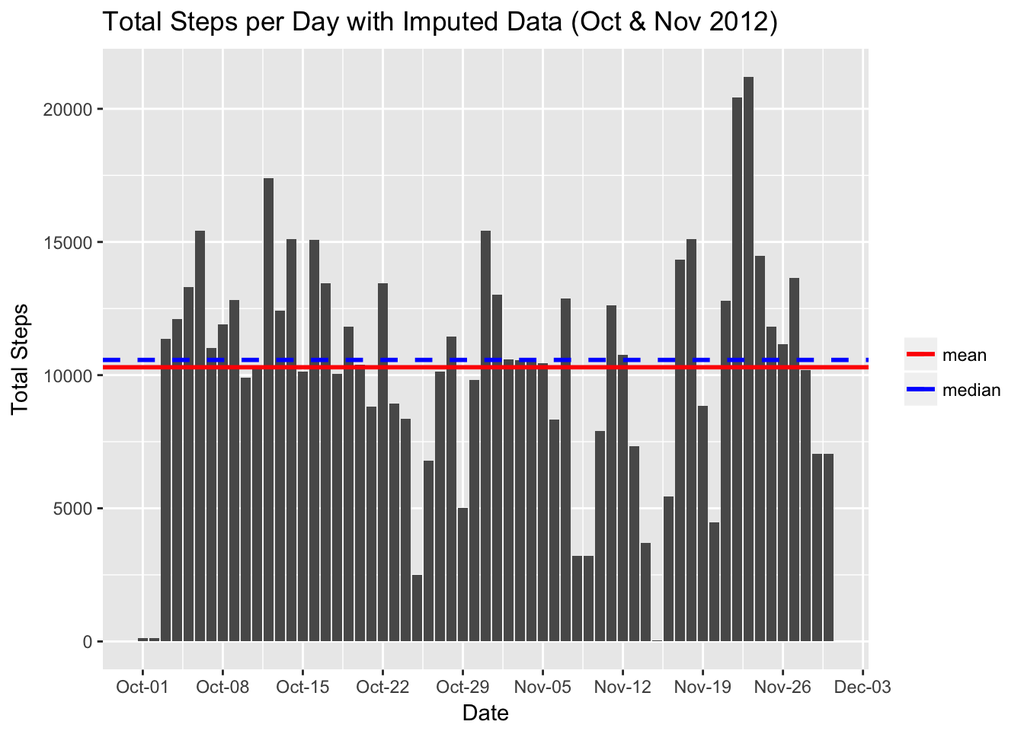

```r
g3b <- ggplot(imputed_days_sum_steps, aes(as.Date(date),tot_mon_steps) ) +
      geom_bar(stat="identity") +
      geom_hline(aes(yintercept=mean(imputed_days_sum_steps$tot_mon_steps,na.rm = TRUE),
                  color = "mean"), lwd = 1, lty = 1) +
      geom_hline(aes(yintercept=median(imputed_days_sum_steps$tot_mon_steps,na.rm = TRUE),
                  color = "median"), lwd = 1, lty = 2) +
      ggtitle("Total Steps per Day with Imputed Data (Oct & Nov 2012)") +
      xlab("Date") + ylab("Total Steps") +
      scale_x_date(date_labels="%b-%d",date_breaks="1 week") +
      scale_color_manual("",breaks = c("mean","median"),
                  values = c("red","blue"))
print(g3b)
```

### Are there differences in activity patterns between weekdays and weekends?

The data collected in the study spans every day during a two month period. The days can be separated into weekdays (Monday-Friday) and weekends (Saturday & Sunday). We’ll group the data, eventually, by weekday or weekend.

Using the `wday()` function from the `lubridate` package, dates are characterized by numbers where Sunday to Saturday are represented by the numbers 1 to 7.

```r
wdays <- c(2,3,4,5,6)
wends <- c(1,7)
```

Find out which elements of the data set are weekdays.

```r
is_wday <- is.element(wday(as.Date(imputed_act_interval$date)),wdays)
```

Add a column to our imputed data set with the entry of `Weekday` for every entry. Then, finding the weekend days, change their label to `Weekend`. Make this column a `factor` variable, giving us a column with two factors.

```r
imputed_act_interval <- mutate(imputed_act_interval,day_of_week="Weekday")
imputed_act_interval$day_of_week[!is_wday] = "Weekend"
imputed_act_interval$day_of_week = as.factor(imputed_act_interval$day_of_week)
```

Now that we’ve got a variable labeling the date as either a weekday or a weekend, we can investigate the steps per interval averaging over all weekdays or weekend days.

Group by the day of the week (`Weekday` or `Weekend`) and interval, and compute the average number of steps for that subset.

```r
imputed_act_interval <- group_by(imputed_act_interval,day_of_week,interval)
imputed_int_avg_steps <- summarize(imputed_act_interval,avg_int_steps = mean(steps))
```

Below is a plot showing the average steps over all days for each interval, using the data set with imputed missing values. The analysis has been separated into days falling under `Weekday` or `Weekend`.

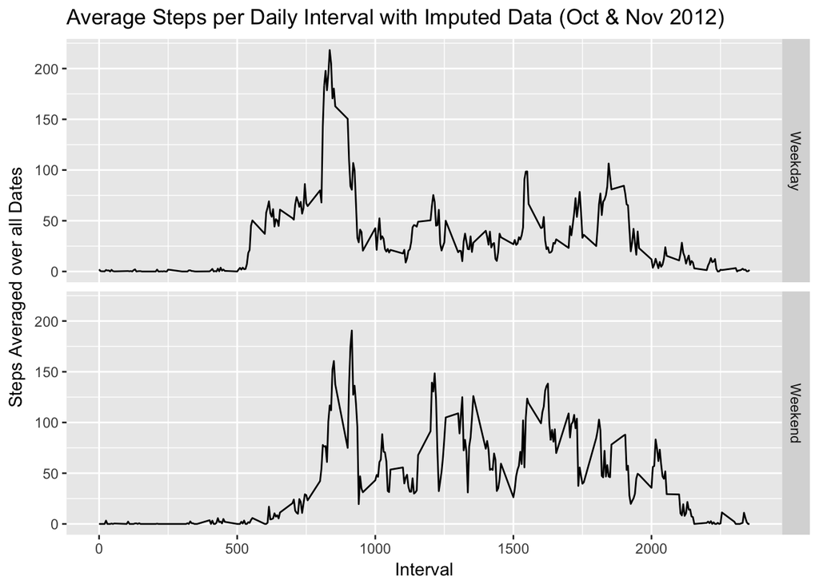

```r
g4 <- ggplot(imputed_int_avg_steps,
             aes(x=interval, y=avg_int_steps)
             ) +
      geom_line() +
      facet_grid(day_of_week~.) +
      ggtitle("Average Steps per Daily Interval with Imputed Data (Oct & Nov 2012)") +
      xlab("Interval") + ylab("Steps Averaged over all Dates")
#      scale_color_manual("",breaks = c("Weekday","Weekend"),
#                  values = c("red","blue"))
print(g4)
```

The analysis seems to show that during a weekday, there are more steps earlier in the morning with less during the day, while weekends have less steps early in the morning and perhaps there are more steps taken throughout the day than during the weekday days.